# Inside Item Memory

# 1 Overview of the data

The rooms were separated into *Familiar* and *Novel* groups. Participants explored the *Familiar* group at the beginning of the experiment. In the encoding task, they visisted both *Familiar* and *Novel* groups. Their item memory (i.e., in which room they saw the item) was tested in the memory test the next day of the encoding task. **Novelty benefits** on the item memory are examined by comparing the memory performance between the *Familiar* and *Novel* groups.

Participants were also asked to rate how curious they felt about the room. The higher the rating is means they felt more curious about the room. Item memory as a function of curiosity rating was also examined for **curiosity benefits**.

Questionnaires on personal traits regarding curiosity were also administered to participants before the encoding task (i.e., PC and EC). Scores on these questionnaires might be able to predict the item memory or its relationship with curiosity rating.

In the encoding task, there were 6 objects in each room. It is possbile that the item memory for the object to some extent depends on the order in which the object was seen. For example, it may be easier to remember where the first and last objects were seen as compared to those in the middle.

# 2 Visual inspection of the data

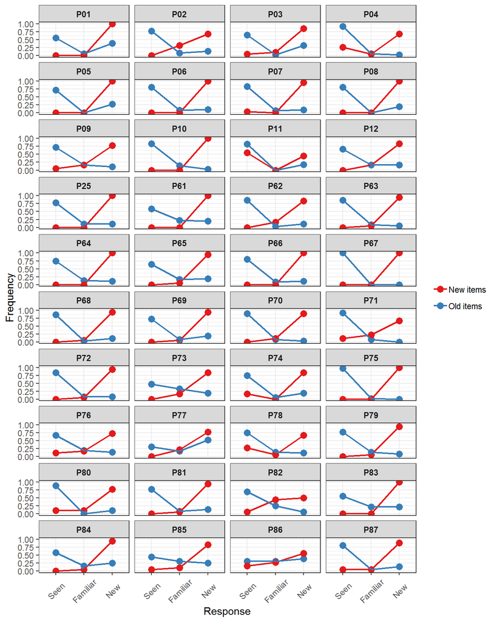

Figure 1. Response frequency for new and old items respectively for each individual participant.

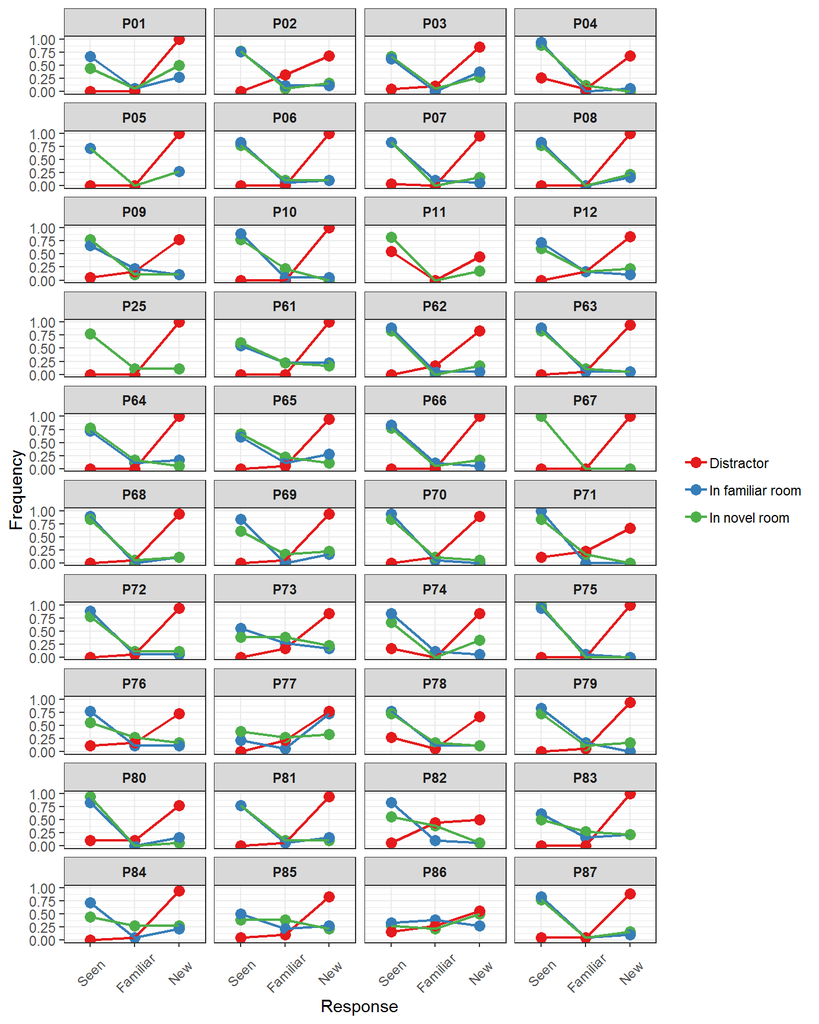

Figure 2. Response frequency for new and old items respectively for each Familiar/Novel group and each individual participant.

# 3 Novelty Benefits

## 3.1 Compare mean accuracy between *novel* and *familiar* rooms

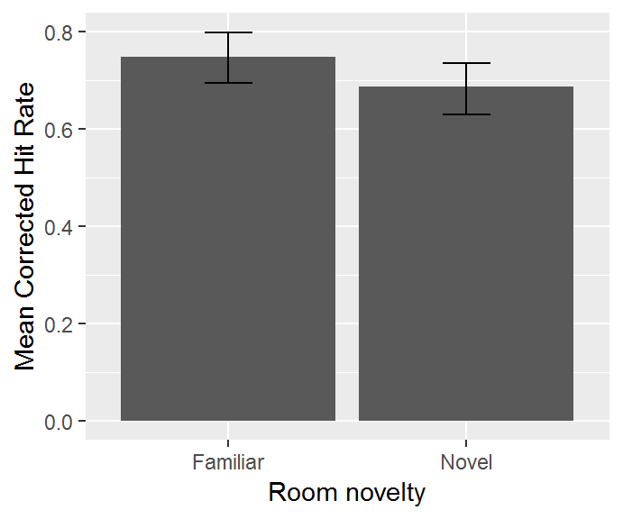

Figure 3. Mean hit rate for recollect response respectively for Familiar and Novel rooms.

Opposite to our prediction.

```
##
##  Paired t-test
##
## data:  MeanCorrSeenHit by Group
## t = 3.6293, df = 39, p-value = 0.0008147
## alternative hypothesis: true difference in means is not equal to 0
## 95 percent confidence interval:
##  0.02664297 0.09372740
## sample estimates:
## mean of the differences
##              0.06018519
```

## 3.2 Item memory as a function of item order

### 3.2.1 Visualise the data

#### 3.2.1.1 Nonlinear

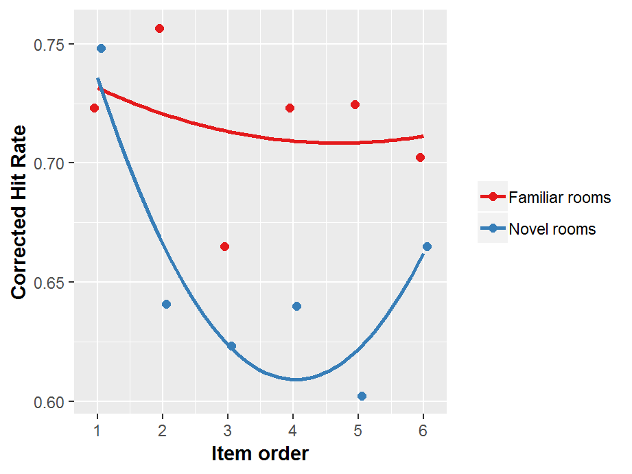

Figure 3. Mean hit rate for seen response at each order (i.e., 1st, 2nd, 3rd, etc), respectively for familiar and novel rooms.

#### 3.2.1.2 Linear

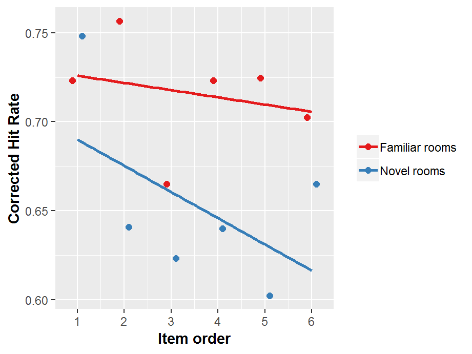

Figure 4. Mean hit rate for seen response at each order (i.e., 1st, 2nd, 3rd, etc), respectively for familiar and novel rooms.

### 3.2.2 Testing novelty effect as a function of item order by fitting mixed models

Build models with item memory accuracy as $y$ and then examine effects of novelty by comparing the models.

```
##                      Model df      AIC      BIC    logLik   Test  L.Ratio
## baseline.item            1  4 99.62234 116.3175 -45.81117
## order.model.linear.1     2  5 99.58093 120.4499 -44.79046 1 vs 2 2.041415
## novelty.model.1          3  6 93.74072 118.7834 -40.87036 2 vs 3 7.840203
## novelty.model.2          4  7 95.06833 124.2848 -40.53417 3 vs 4 0.672391
##                      p-value
## baseline.item
## order.model.linear.1  0.1531
## novelty.model.1       0.0051
## novelty.model.2       0.4122
```

No interaction.

#### 3.2.2.1 Parameter estimation for the complete model

```
##                    Value   Std.Error  DF   t-value      p-value
## (Intercept)  0.748667580 0.038273250 399 19.561119 3.123927e-60
## ItemOrder   -0.009395833 0.006530595 399 -1.438741 1.510080e-01
## GroupNovel  -0.062534722 0.022309404  39 -2.803066 7.845591e-03
```

### 3.2.3 Collapse the order and novelty group

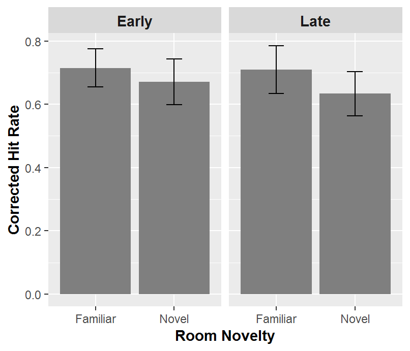

#### 3.2.3.1 Stats on it

```
##               Model df        AIC       BIC   logLik   Test  L.Ratio
## baseline          1  5  -99.72966 -84.35379 54.86483
## NoveltyModel      2  6 -106.20927 -87.75823 59.10463 1 vs 2 8.479610
## OrderModel        3  7 -105.33245 -83.80623 59.66623 2 vs 3 1.123182
## repeatedModel     4  8 -103.93829 -79.33690 59.96914 3 vs 4 0.605836
##               p-value
## baseline
## NoveltyModel   0.0036
## OrderModel     0.2892
## repeatedModel  0.4364
```

```
##                                     Value  Std.Error DF    t-value
## (Intercept)                   0.714879386 0.03450294 78 20.7193763
## GroupNovel                   -0.044444444 0.02885160 39 -1.5404500
## ItemOrderTypeLate            -0.005753968 0.02885160 78 -0.1994333
## GroupNovel:ItemOrderTypeLate -0.031398810 0.04080232 78 -0.7695349
##                                   p-value
## (Intercept)                  1.889648e-33
## GroupNovel                   1.315262e-01
## ItemOrderTypeLate            8.424428e-01
## GroupNovel:ItemOrderTypeLate 4.439000e-01
```

Main effect of novelty, but in opposite direction. No interaction.

# 4 Curiosity Benefits

We hypothesed that the higher the curiosity rating was, the better the item memory should be.

## 4.1 Mean accuracy of item memory as a function of curiosity rating

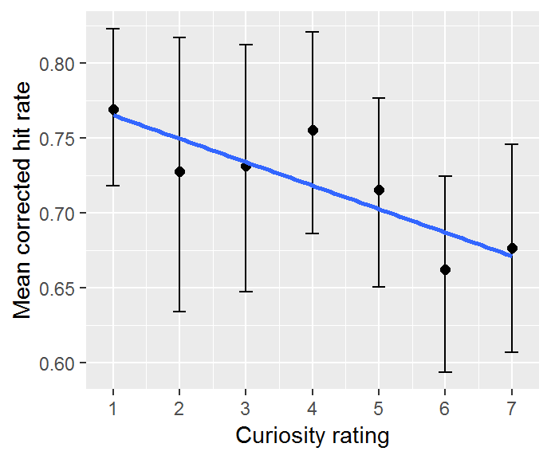

Figure 6. Mean hit rate as a function of curiosity rating.

### 4.1.1 Testing the relationship between mean accuracy of item memory and curiosity rating

Build models with item memory accuracy as $y$ and examine effects of curiosity rating by including it into the model and then comparing the model fits.

- `baseline.rating` is the model with only an intercept, showing no change in item memory as a function of curiosity rating.
- `rating.intercept` is the model with $\small CuriosityRating$ included, showing the effects of curiosity rating.
- `rating.slope` is the model allowing the slope (i.e., relationship between item memory and curiosity rating) varying across participants.

```
##                  Model df       AIC        BIC   logLik   Test  L.Ratio
## baseline.rating      1  3 -112.3701 -101.94073 59.18506
## rating.intercept     2  4 -119.5437 -105.63782 63.77184 1 vs 2 9.173556
## rating.slope         3  6 -115.5379  -94.67912 63.76895 2 vs 3 0.005778
##                  p-value
## baseline.rating
## rating.intercept  0.0025
## rating.slope      0.9971
```

#### 4.1.1.1 Parameter estimates in the complete model

```r
summary(rating.slope)
```

```
## Linear mixed-effects model fit by maximum likelihood
##  Data: InsideObjectsMemory
##         AIC       BIC   logLik
##   -115.5379 -94.67912 63.76895
##
## Random effects:
##  Formula: ~1 + CuriosityRating | SubjectNo
##  Structure: General positive-definite, Log-Cholesky parametrization
##                 StdDev       Corr
## (Intercept)     0.1426929264 (Intr)
## CuriosityRating 0.0005560412 -0.003
## Residual        0.1600753168
##
## Fixed effects: CorrSeenHit ~ CuriosityRating
##                      Value  Std.Error  DF   t-value p-value
## (Intercept)      0.7839576 0.03298526 198 23.766907  0.0000
## CuriosityRating -0.0162516 0.00532670 198 -3.050979  0.0026
##  Correlation:
##                 (Intr)
## CuriosityRating -0.655
##
## Standardized Within-Group Residuals:
##        Min         Q1        Med         Q3        Max
## -2.8014732 -0.5847532  0.1213649  0.6291133  2.3721278
##
## Number of Observations: 239
## Number of Groups: 40
```

Opposite to our prediction.

#### 4.1.1.2 Plot the model

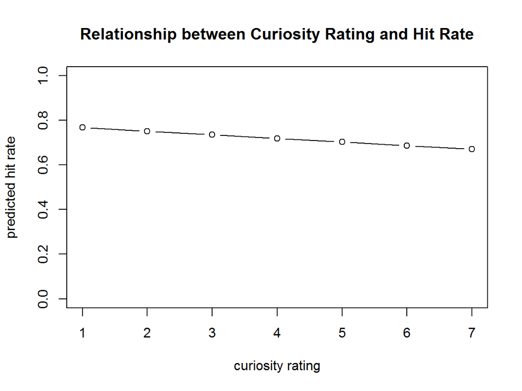